# Linked fate lit. review

Jae Yeon Kim

# 1. Data Collection

I searched linked fate related articles using Google scholar. I used two search queries: (1) “linked fate” + “dawson” and (2) “linked fate” + “group consciousness” + “solidarity”. (1) is a narrow search which only found articles that are directly related to Dawson’s origianl work. (2) is a abroad search which found articles that are broadly related to the topcis that Dawson discussed in his book. I avoided collecting data on books, book chapters, and book reviews since most of them don’t deal with origianl empirical research. I searched up to 150 results using each search query and deleted the duplicates. Of course, this data are not exhausitive but they at least provide some systematic evidence on the scholarly works on linked fate.

## The total N of articles

First, let’s look at the total N of articles.

```
## The total number of articles is 103
```

Some articles are lit reviews or law review artices or thoeretical pieces that don’t discuss data. Let’s exclude them.

```
## The total number of empirical articles is 89
```

```
## The percentage of empirical articles in the data is 0.8640777
```

```
## The total number of journals in the data is 44
```

## Overall patterns

An overall publication pattern on linked fate. Articles publisehd in recent years are less likely to be included in the data due to their less well-known status. That may explain why there are fewer articles in the past few years.

### Publication trend on linked fate

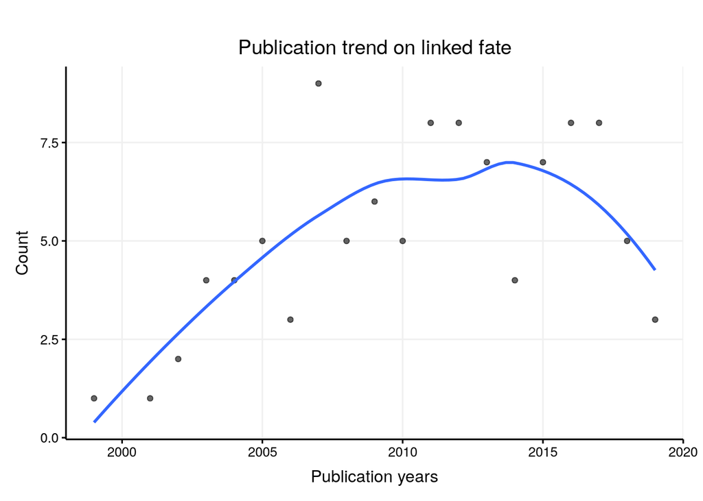

### Publication on linked fate by subject group

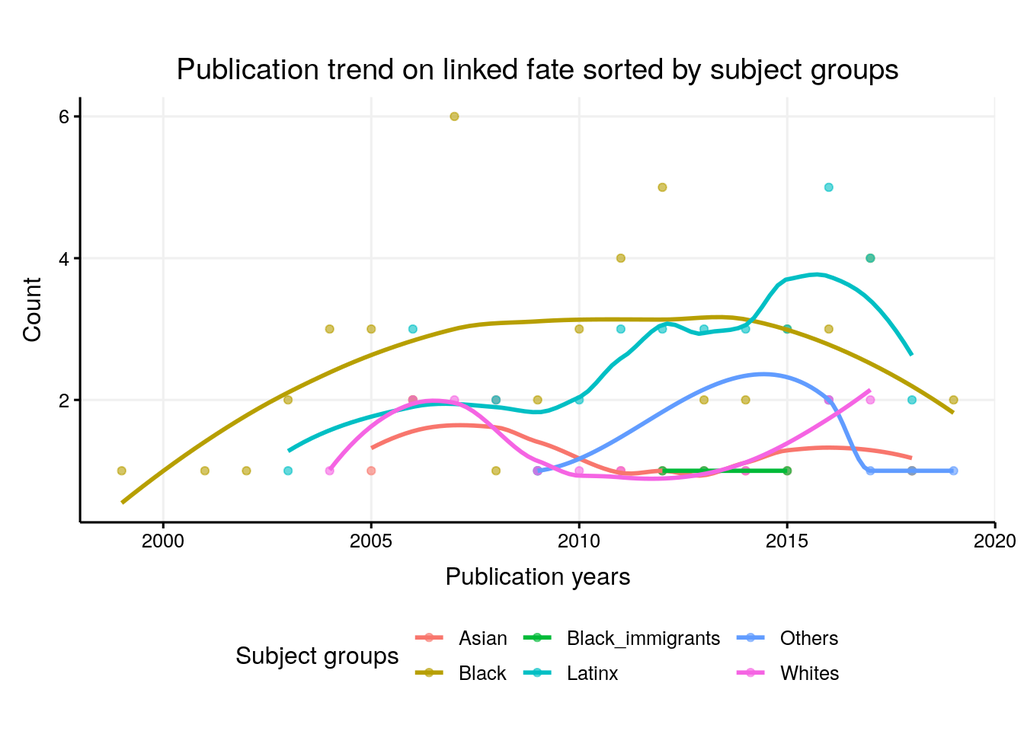

## Journal patterns

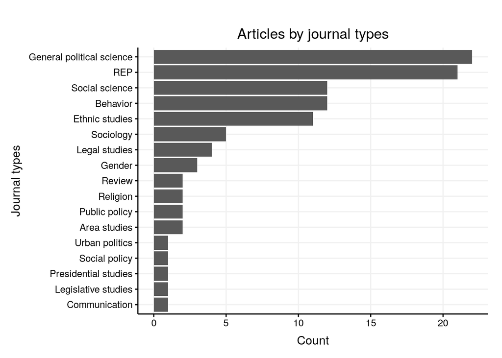

## Data patterns

Note that these counts are not mutually exclusive. For instance, some studies use surveys plus experimens or qualitative evidence (interviews). Since methods follow trends, I did line rather than bar plotting.

1. Survey: relying on survey data
2. Experiment: relying on experimental data
3. Qualitative: relying on qualitative evidence (e.g., interviews)

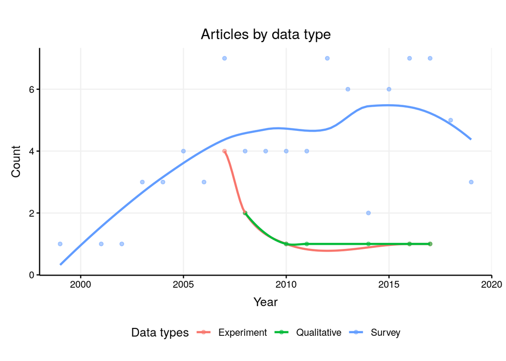

# Key takeaways